# Week 7: Contribute to a Package

In the last module, you took a look at the [`meangirls`](https://github.com/Cal-Poly-Advanced-R/meangirls) package by Regina George. Now let’s help Regina make her package even better.

The `usethis` package will make this process easy and foolproof. Make sure you have it installed now!

**Time Estimates:**  
Videos: 30 sec  
Readings: 20 min  
Activities: 40 min  
Check-ins: 5

**Extra Resources:**

- [Pull Requests with usethis](https://usethis.r-lib.org/articles/articles/pr-functions.html)
- [Why you should contribute to Open Source](https://medium.com/@austintackaberry/why-you-should-contribute-to-open-source-software-right-now-bec8bd83cfc0)

## 1 Get set up

The first thing you need to do when you want to contribute to someone else’s package is to **fork** the package. Recall that a **fork** is very different from a **clone**. A *clone* simply copy-pastes the repository, while a *fork* retains its link to the original repository.

Now, we could go through the tedious process of *forking* the repository, then all the steps after that to get it open in your local computer’s RStudio. Instead, let’s do all these steps in one with `usethis`. Open up a new RStudio session, load the `usethis` package, and then run:

```r
create_from_github("Cal-Poly-Advanced-R/meangirls")
```

A lot of output will print out.

Here’s what this does:

- Forks the `meangirls` repo, owned by `Cal-Poly-Advanced-R` on GitHub, into your GitHub account.
- Clones your repo into a folder named “meangirls” on your desktop (or similar).
- Does additional git/GitHub setup:
  - Sets your *origin remote* (the repo you can push directly to) to be your own forked copy of the “meangirls” repo.
  - Sets your *upstream remote* (the original version that you will later Pull Request) to be the “meangirls” repo owned by `Cal-Poly-Advanced-R`
  - Sets the *main branch* to be the original repo’s main branch, so you can pull future edits that Regina makes (“upstream changes”) in the future.
- Opens a new instance of RStudio in the `meangirls` R project.

#### Alternative approach

It is also possible to do this steps without `create_from_github()`, if you prefer or if it is not playing nice with your machine.

1. On GitHub, navigate to [the package repo](https://github.com/Cal-Poly-Advanced-R/meangirls) and click “Fork”.
2. Using GitHub Desktop (or your preferred method), clone your new forked package to your local machine.
3. Navigate to the folder where you cloned the package, and open the `.Rproj`.

**Check-In 1: Forking setup**

Take a screenshot of the console output from `create_from_github()`

OR

Take a screenshot of your RStudio window with the package project open.

## 2 Make some simple changes

We are now ready to get our hands dirty with this package.

First, **build the package**.

[figure not shown]

Open up **README.Rmd** and knit it. Scroll to the very bottom. Do you see a problem with the output? It’s time to fix the `give_candygrams()` function so that it includes extra messages.

But first, we need to make a **branch** of our repo, so that when we change the code, it is carefully tracked separately.

In your console, type:

```r
pr_init("fix-candygrams")
```

This will switch you to a new branch.

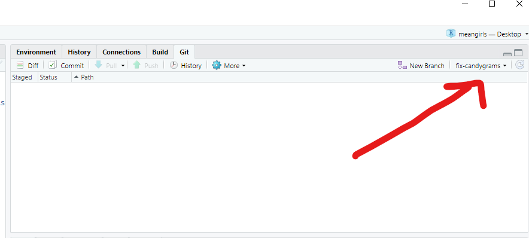

Now, we can finally edit the source code!

- Fix the code in `give_candygrams.R` so that the extra messages print out properly. *Hint: This is a small change in only one line of the code!*
- Check that the code is fixed by re-building the package, re-knitting the `README.Rmd` file, and looking at the output at the bottom.
- When you are satisfied with your change, **commit your changes** to Git.
- Then run in the console:

```r
pr_push()
```

This will magically pop up a Pull Request window, like the one from Week 1!

**Check-In 2: PR Edits**

Complete the Pull Request. Take a screenshot of the “Files Changed” tab of the Pull Request screen.

*Unlike Week 1, I will NOT be merging your Pull Requests.*

## 3 Testing packages

Last, let’s check out the **unit tests** in Regina’s package.

In any package, it’s very important to write automatic tests to check that your functions work the way you hope. As the package gets more complex, you can then keep running your tests to make sure nothing broke along the way.

Run the tests that Regina has written for her package by typing `Ctrl/Cmd-Shift-T`; or from the drop-down menu in the Build pane:

[figure not shown]

Oh no! One of the unit tests failed.

In the folder `tests/testthat`, find the appropriate test file. Figure out how the actual output was different from the expected output.

**Check-In 3: More PR Edits**

Start a new pull request using `pr_init()`, as you did above.

Track down the error, and make changes to the function. Keep trying until all tests succeed.

When you are done, finish off the pull request, and take a screenshot.

## 4 Make a major contribution

When handing out candygrams, Santa has a whole classroom of students to announce.

**Required Video: [CandyCane Grams](https://www.youtube.com/embed/nnjWmz4lB2U)**

[video not shown]

*Honestly, this whole movie is required viewing.*

It would be tedious to have to call the `give_candygrams()` function once for each student. Instead, it would be convenient to have a vector of student names and a vector of candygram counts, and run a single function like so:

```r
students <- c("Taylor Zimmerman", "Glen Coco", "Cady Heron", "Gretchen Weiners")
counts <- c(2, 4, 1, 1)


give_many_candygrams(students, counts)
```

**Check-In 4: Contribute a function**

1. Write the function `give_many_candygrams()` into the `meangirls` package.
2. Do your best to copy the documentation style of the `give_candygrams()` function. Type `Ctrl-Shift-D`, or use the Build pane drop-down menu, to automatically write a documentation file for your function.
3. Re-build the package. Then type `?give_many_candygrams` in your console.
4. **Take a screenshot of the “Help” pane that pops up.** It should look like this, except for your new function:

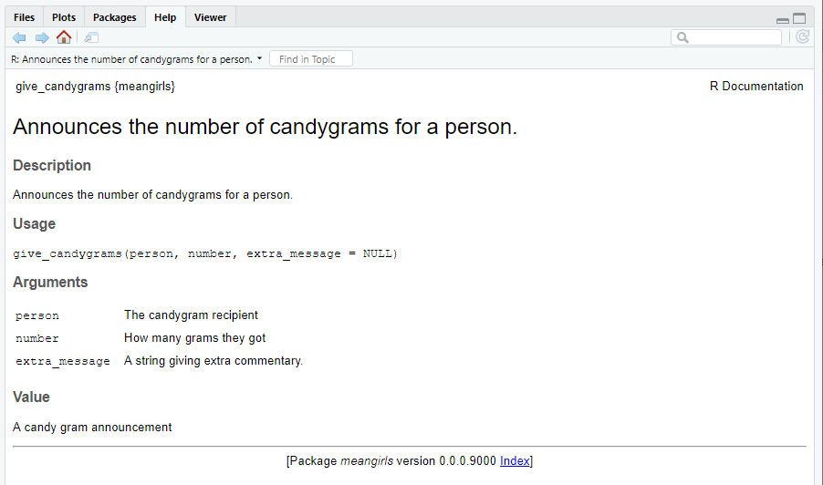

**Check-In 5: Write a Unit Test**

Type in your console:

```r
use_test("give_many_candygrams")
```

Edit the file that pops up, to create a unit test for your new `give_many_candygrams` function.

Re-run the tests for the package.

Once all the tests pass, **take a screenshot of the Build pane**.

It should look like this, but with a total of 7 tests:

[figure not shown]